# **HOUSING PRICES, LANDMARKS AND PLACES OF INTEREST**

# Results obtained by fitting a regression model into the housing data

1. **Carlton**: The housing prices in Carlton are experiencing a moderate increase, with a coefficient of $33,087.54.
2. **Docklands**: Docklands shows a similar trend to Carlton, with housing prices increasing at a rate of $25,524.17.
3. **East Melbourne**: Housing prices in East Melbourne are rising significantly, with a coefficient of $45,675.22.
4. **Kensington**: Kensington is experiencing a moderate increase in housing prices, with a coefficient of $24,425.97.
5. **Melbourne (CBD)**: The CBD area of Melbourne shows a relatively lower increase in housing prices, with a coefficient of $12,765.61.
6. **Melbourne (Remainder)**: Similar to the CBD, the remainder of Melbourne shows a moderate increase in housing prices, with a coefficient of $20,100.73.
7. **North Melbourne**: Housing prices in North Melbourne are moderately increasing, with a coefficient of $31,334.58.
8. **Parkville**: Parkville exhibits a significant increase in housing prices, with a coefficient of $37,859.78.
9. **South Yarra**: South Yarra shows a moderate increase in housing prices, with a coefficient of $32,274.16.
10. **Southbank**: Housing prices in Southbank are increasing at a relatively lower rate, with a coefficient of $15,680.43.
11. **West Melbourne (Residential)**: West Melbourne (Residential) is experiencing a moderate increase in housing prices, with a coefficient of $33,115.74.

# Type of Houses for which Property Transactions took place in each Suburbs

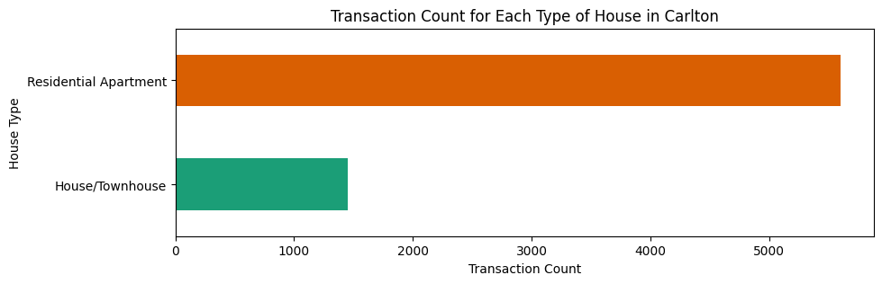

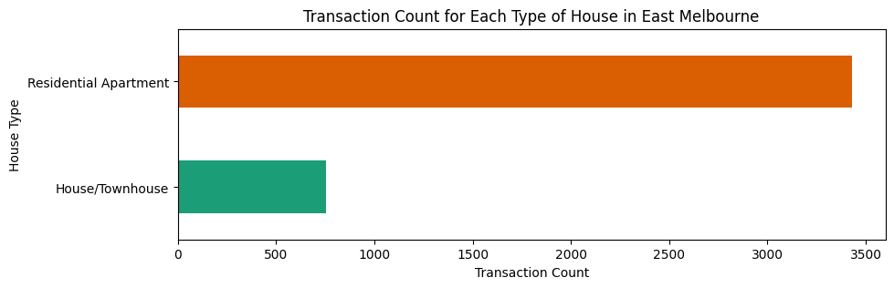

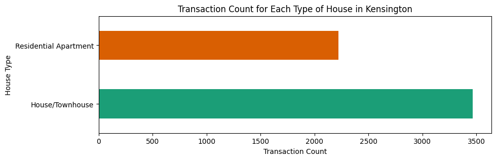

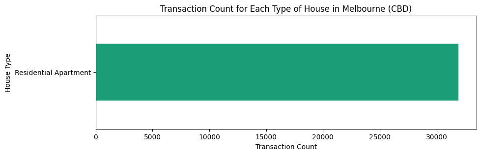

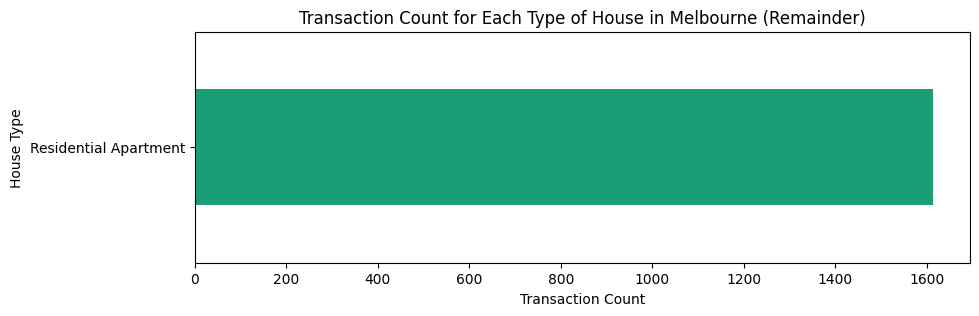

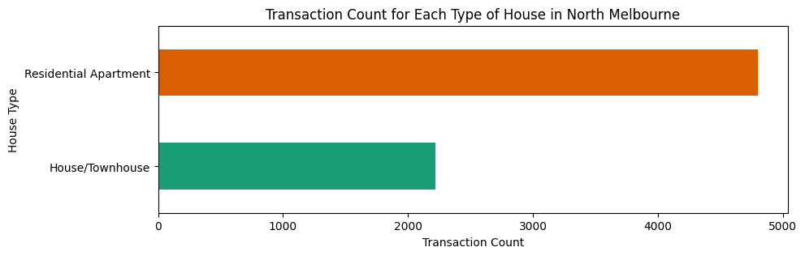

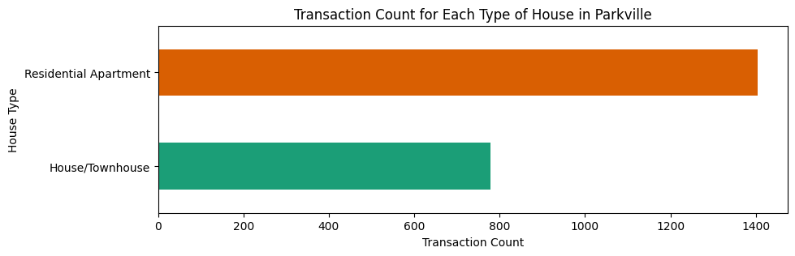

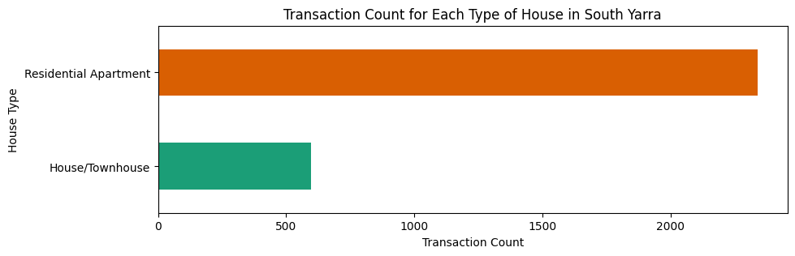

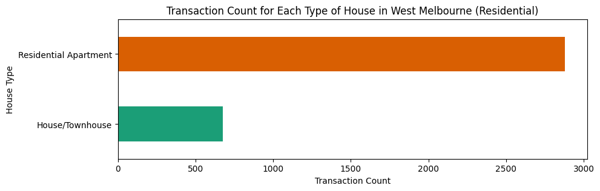

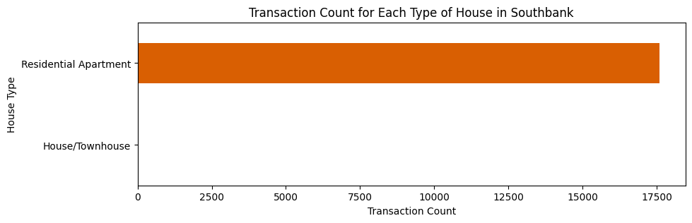

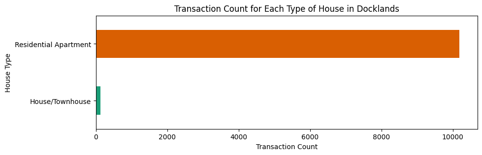

```python
from matplotlib import pyplot as plt
import seaborn as sns



for suburb_name in unique_Small_Areas:
    # Filter the DataFrame for the specific suburb
    suburb_data = housing_price[housing_price['Small_Area'] == suburb_name]
    plt.figure(figsize=(10,3))
    # Group by 'Type' and sum the 'Transaction_Count' for each Type
    suburb_transaction = suburb_data.groupby('Type')['Transaction_Count'].sum()

    # Plot the transaction count for each Type of house as a horizontal bar plot
    suburb_transaction.plot(kind='barh', color=sns.color_palette('Dark2'))

    # Set the title and labels

    plt.title(f'Transaction Count for Each Type of House in {suburb_name}')
    plt.xlabel('Transaction Count')
    plt.ylabel('House Type')

    # Show the plot
    plt.show()
```

# Type of Houses for which Property Transactions took place in each Suburbs over the years

```python
import plotly.graph_objects as go

# Iterate over unique_Small_Areas
for suburb_name in unique_Small_Areas:
    dataset = suburb_datasets[suburb_name].sort_values(by='Sale_Year')

    fig = go.Figure()

    for house_Type in house_Types:
        # Filtering dataset for house Type
        house_data = dataset[dataset['Type'] == house_Type]

        # Add a trace for the current house Type
        fig.add_trace(go.Bar(x=house_data['Sale_Year'], y=house_data['Transaction_Count'], name=house_Type))

    # Update layout
    fig.update_layout(title=f'Transaction Count in {suburb_name} Over the Years',
                      xaxis_title='Sale Year',
                      yaxis_title='Transaction count')

    # Show the plot for the current suburb
    fig.show()
```

[interactive chart not shown]

# Loading the [Landmarks and Places of interest](https://https://data.melbourne.vic.gov.au/explore/dataset/landmarks-and-places-of-interest-including-schools-theatres-health-services-spor/table/) Dataset

```python
# Function to get data from website using API
def get_data(base, data_url, offset=0):
    # Set the filters, limit retrieves 20 rows at a time, offset says where to start data collection
    filters = f'records?limit={50}&offset={offset}&timezone=UTC'
    # Make the url from base, data url and filters variables stored ouside loop
    url = f'{base}{data_url}/{filters}'
    # Use the requests function to get the data
    result = requests.get(url)
    # Check that the request works, error code 200 = successful
    if result.status_code == 200:
        # Save results as a json file
        result_json = result.json()
        # Store a variable of max_results with total of dataset
        max_results = result_json['total_count']
        # Save the results key data to a list variable
        records = result_json['results']
    else:
        # If data is not collected correctly return the error
        print("ERROR GETTING DATA: ", result.status_code)
        max_results = 0
        records = []
    # At end of function, return the json results in records, max_results count and offset
    return [records, max_results, offset]



# Collect data from API
# Set offset increment
# (needs to match offset in get data function)
OFFSET_INCREMENT = 50
# Base url (this should be the same for all datasets)
BASE_URL = 'https://data.melbourne.vic.gov.au/api/explore/v2.1/catalog/datasets/'
# Set specific url
# (change this variable for the dataset you are working with)
SPECIFIC_PATH = 'landmarks-and-places-of-interest-including-schools-theatres-health-services-spor'
# Call the get data function, passing in variables above, save to result
result = get_data(BASE_URL, SPECIFIC_PATH)
# Save the records data returned in the get_data function to records list variable
records = result[0]
# Save the dataset size data returned in the get_data function to max_results variable
max_results = result[1]
# Increase the offset returned in the get_data function (result[2]) by the offset increment
offset = result[2] + OFFSET_INCREMENT
# Check the length of the data returned and compare it against the max_results variable
# If the length o fthe data is less than the max_results, run the while loop
while len(records) != max_results:
    # Call the get data function again, passing in url, specific path and new offset value
    data = get_data(BASE_URL, SPECIFIC_PATH, offset)
    # Add the data collected to the existing records list
    records += data[0]
    # Increase the offset by the offset increment
    offset += OFFSET_INCREMENT
# Convert the records list of dictionaries into a pandas dataframe
lndmvrks = pd.DataFrame(records)
# Print the dataframe
lndmvrks.head()
```

|  | theme | sub_theme | feature_name | co_ordinates |
| --- | --- | --- | --- | --- |
| 0 | Transport | Railway Station | Flemington Bridge Railway Station | {'lon': 144.939277838304, 'lat': -37.788164588... |
| 1 | Mixed Use | Retail/Office/Carpark | Council House 2 (CH2) | {'lon': 144.966638432727, 'lat': -37.814259143... |
| 2 | Leisure/Recreation | Informal Outdoor Facility (Park/Garden/Reserve) | Carlton Gardens South | {'lon': 144.971266479841, 'lat': -37.806068457... |
| 3 | Place of Worship | Church | Wesley Church | {'lon': 144.968168215633, 'lat': -37.810157644... |
| 4 | Place of Worship | Church | St Augustines Church | {'lon': 144.954862000132, 'lat': -37.816974135... |

```python
lndmvrks = pd.read_csv("https://data.melbourne.vic.gov.au/api/explore/v2.1/catalog/datasets/landmarks-and-places-of-interest-including-schools-theatres-health-services-spor/exports/csv?lang=en&timezone=Australia%2FSydney&use_labels=true&delimiter=%2C")
```

# Classification of Landmarks and Places of Interests

**In the following sections we classify and visualise the Landmarks and Places of Interests on the basis of Type based on 'Theme' column.**

```python
theme_counts = lndmvrks['Theme'].value_counts()
print( theme_counts)
```

```
Theme
Leisure/Recreation                      63
Place Of Assembly                       40
Place of Worship                        31
Transport                               26
Community Use                           21
Education Centre                        13
Mixed Use                               11
Health Services                         11
Office                                  11
Purpose Built                            4
Vacant Land                              3
Retail                                   3
Residential Accommodation                2
Warehouse/Store                          1
Specialist Residential Accommodation     1
Industrial                               1
Name: count, dtype: int64
```

```python
# Create a pie chart
fig = go.Figure(data=[go.Pie(labels=theme_counts.index, values=theme_counts, textinfo='percent', hole=0.3)])

# Update layout
fig.update_layout(title='Distribution of Themes in Landmarks',
                  legend_title='Themes',
                  legend=dict(orientation='v', yanchor='top', y=1.0, xanchor='right', x=1.25),
                  margin=dict(l=20, r=20, t=40, b=20))

fig.show()
```

[interactive chart not shown]

# Creating subplots for each theme

**Creating subplots for each Type of landmark in order to show the sub Types of landmarks and places of interests.**

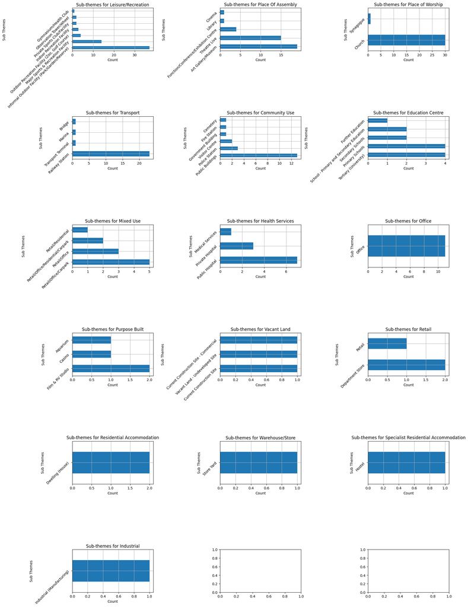

```python
import matplotlib.pyplot as plt

# Get the theme counts
theme_counts = lndmvrks['Theme'].value_counts()

num_themes = len(theme_counts)
num_cols = 3  # Maximum number of columns per row
num_rows = (num_themes + num_cols - 1) // num_cols

# Creating subplots for each theme
fig, axes = plt.subplots(nrows=num_rows, ncols=num_cols, figsize=(18, num_rows*4))

for i, theme in enumerate(theme_counts.index):
    theme_df = lndmvrks[lndmvrks['Theme'] == theme]

    # Count occurrences of sub-themes
    sub_theme_counts = theme_df['Sub Theme'].value_counts()

    # Plot the sub-themes
    ax = axes[i//num_cols, i%num_cols]  # Calculate subplot index
    sub_theme_counts.plot(kind='barh', ax=ax)
    ax.set_title(f'Sub-themes for {theme}')
    ax.set_xlabel('Count')
    ax.set_ylabel('Sub Themes')
    ax.tick_params(axis='y', rotation=45)
    ax.grid(True)

# Adjust layout
plt.tight_layout()
plt.show()
```

# Mapping Landmarks and Places of Interests

```python
# Converting coordinates
lndmvrks['Latitude'] = [float(coord.split(',')[0]) for coord in lndmvrks['Co-ordinates']]
lndmvrks['Longitude'] = [float(coord.split(',')[1]) for coord in lndmvrks['Co-ordinates']]

# Creating a map
map_center = [lndmvrks['Latitude'].mean(), lndmvrks['Longitude'].mean()]
mymap = folium.Map(location=map_center, zoom_start=12)

# Add markers for each coordinate
for i in range(len(lndmvrks)):
    folium.Marker(
        location=[lndmvrks['Latitude'][i], lndmvrks['Longitude'][i]],
        popup='Landmark Name: {}'.format(lndmvrks['Feature Name'][i])
    ).add_to(mymap)

# Save the map as an HTML file
mymap
```

Make this Notebook Trusted to load map: File -> Trust Notebook

[interactive chart not shown]

# Map Showing the Suburb Regions and Landmarks

**Mapping out suburb regions from the Small-Areas-for-Census-of -Landuse dataset. The suburb regions are given as a set of co-ordinate points which need to be mapped out in order to represent the suburb.**

```python
suburbs_data = pd.read_csv("https://data.melbourne.vic.gov.au/api/explore/v2.1/catalog/datasets/small-areas-for-census-of-land-use-and-employment-clue/exports/csv?lang=en&timezone=Australia%2FSydney&use_labels=true&delimiter=%2C")
```

```python
import geopandas as gpd

url = 'https://github.com/yashdawaree/Capstone/raw/main/small-areas-for-census-of-land-use-and-employment-clue.geojson'
gdf = gpd.read_file(url)


gdf.rename(columns={'featurenam': 'suburb'}, inplace=True)

print("Small Areas for Census of Land Use and Employment (CLUE) Dataset: \n")
gdf.head()
```

```
Small Areas for Census of Land Use and Employment (CLUE) Dataset:
```

|  | geo_point_2d | suburb | shape_area | shape_len | geometry |
| --- | --- | --- | --- | --- | --- |
| 0 | {'lon': 144.9204996881507, 'lat': -37.79152998... | Kensington | 3808797.49677 | 9407.05542058 | MULTIPOLYGON (((144.93687 -37.78884, 144.93667... |
| 1 | {'lon': 144.94942867521925, 'lat': -37.8084601... | West Melbourne (Residential) | 860054.675679 | 4031.46799307 | MULTIPOLYGON (((144.95144 -37.81317, 144.95033... |
| 2 | {'lon': 144.96291513859617, 'lat': -37.8138110... | Melbourne (CBD) | 2485904.89194 | 7112.60987105 | MULTIPOLYGON (((144.95144 -37.81317, 144.95392... |
| 3 | {'lon': 144.97838992382978, 'lat': -37.8287640... | Melbourne (Remainder) | 2668300.95898 | 11399.6082458 | MULTIPOLYGON (((144.98502 -37.84568, 144.98420... |
| 4 | {'lon': 144.9515603312268, 'lat': -37.78711656... | Parkville | 4050997.2362 | 9224.56939673 | MULTIPOLYGON (((144.94037 -37.78762, 144.94007... |

```python
# Loading GeoJSON file
geojson_file = "small-areas-for-census-of-land-use-and-employment-clue.geojson"
gdf = gpd.read_file(geojson_file)
```

```python
gdf.rename(columns={'featurenam': 'suburb'}, inplace=True)
```

# Identifing the suburbs in which the Landmarks and places of interests are located

**Using the co-ordinate location of Landmarks and Places of interests to map them overlaying with the suburbs.**

```python
import geopandas as gpd
import folium

# Creating a map for the suburbs
map_center = [gdf['geometry'].centroid.y.mean(), gdf['geometry'].centroid.x.mean()]
mymap = folium.Map(location=map_center, zoom_start=14)
color= 'blue'
for idx, feature in gdf.iterrows():

    # Extracting suburb name
    feature_name = feature['suburb']

    popup_content = f'<b style="font-size: 16px">{feature_name}</b>'
    folium.GeoJson(
        feature['geometry'],
        style_function=lambda x: {'fillColor': color, 'color': color},
          popup=folium.Popup(popup_content, max_width=300),
    ).add_to(mymap)

# Adding locations of Landmarks and Places of Interest
for i in range(len(lndmvrks)):
    folium.Marker(
        location=[lndmvrks['Latitude'][i], lndmvrks['Longitude'][i]],
        popup='Landmark Name: {}'.format(lndmvrks['Feature Name'][i]),
        icon=folium.Icon(color='red')
    ).add_to(mymap)

# Display the map
mymap
```

Make this Notebook Trusted to load map: File -> Trust Notebook

[interactive chart not shown]

```python
from geopy.distance import geodesic


# extracting coordinates from Geo Point column
def extract_coordinates(geo_point):
    # Geo Point is in format "latitude, longitude"
    lat, lon = map(float, geo_point.split(','))
    return lat, lon

# Function to calculate distance between two points
def calculate_distance(landmark_coords, suburb_coords):
    return geodesic(landmark_coords, suburb_coords).kilometers

# List to store the suburb for each landmark
lmk_suburbs = []

# Iterate over each landmark
for landmark_coords in lndmvrks['Co-ordinates']:
    # Initialize variables to store minimum distance and corresponding suburb
    min_distance = float('inf')
    closest_suburb = None

    # Iterate over each suburb
    for index, suburb_data in suburbs_data.iterrows():
        suburb_coords = extract_coordinates(suburb_data['Geo Point'])

        # Calculating distance between landmark and suburb
        distance = calculate_distance(landmark_coords, suburb_coords)

        if distance < min_distance:
            min_distance = distance
            closest_suburb = suburb_data['featurenam']


    lmk_suburbs.append(closest_suburb)

# Adding the suburb information to the lndmvrks
lndmvrks['suburb'] = lmk_suburbs

sub_lmrks = lndmvrks.drop(columns=['Co-ordinates'], inplace=True)

lndmvrks.head()
```

|  | Theme | Sub Theme | Feature Name | Latitude | Longitude | suburb |
| --- | --- | --- | --- | --- | --- | --- |
| 0 | Transport | Railway Station | Flemington Bridge Railway Station | -37.788165 | 144.939278 | Parkville |
| 1 | Mixed Use | Retail/Office/Carpark | Council House 2 (CH2) | -37.814259 | 144.966638 | Melbourne (CBD) |
| 2 | Leisure/Recreation | Informal Outdoor Facility (Park/Garden/Reserve) | Carlton Gardens South | -37.806068 | 144.971266 | Melbourne (CBD) |
| 3 | Place of Worship | Church | Wesley Church | -37.810158 | 144.968168 | Melbourne (CBD) |
| 4 | Place of Worship | Church | St Augustines Church | -37.816974 | 144.954862 | Melbourne (CBD) |

# Count and Type of Landmarks in each Suburb

**Landmarks by Sub Theme**

Classifying landmarks into various Types based on the 'theme' and sub Types nased on the 'sub theme' columns from the Landmarks and Places of Interests Datasets.

```python
import plotly.graph_objects as go
import pandas as pd

# Group by 'suburb' and 'Theme'
landmark_counts_by_Type = lndmvrks.groupby(['suburb', 'Theme']).size().unstack(fill_value=0)

# Create traces for each theme
data = []
for theme in landmark_counts_by_Type.columns:
    data.append(go.Bar(
        x=landmark_counts_by_Type.index,
        y=landmark_counts_by_Type[theme],
        name=theme
    ))

# Layout
layout = go.Layout(
    title='Total Number of Landmarks by Type for Each Suburb',
    xaxis=dict(title='Suburb'),
    yaxis=dict(title='Number of Landmarks'),
    barmode='stack',
    xaxis_tickangle=-45
)

# Create figure
fig = go.Figure(data=data, layout=layout)

fig.show()
```

[interactive chart not shown]

**Categorising the landmarks from the Landmarks and Places of Interest dataset into Suburbs using spatial data.**

```python
# Grouping "suburb" column and count the number of landmarks in each area
landmark_counts = lndmvrks.groupby('suburb')['Feature Name'].size()

landmark_counts_df = landmark_counts.reset_index()
landmark_counts_df.columns = ['suburb', 'Landmark_Count']
Suburb_data_with_landmarks = pd.merge(gdf, landmark_counts_df, on='suburb', how='left')

Suburb_data_with_landmarks.rename(columns={'Shape_area': 'Suburb_Area'}, inplace=True)

# Selecting only the desired columns
landmarks_in_suburb = Suburb_data_with_landmarks[['suburb', 'shape_area', 'Landmark_Count']].sort_values(by='Landmark_Count', ascending=False)
```

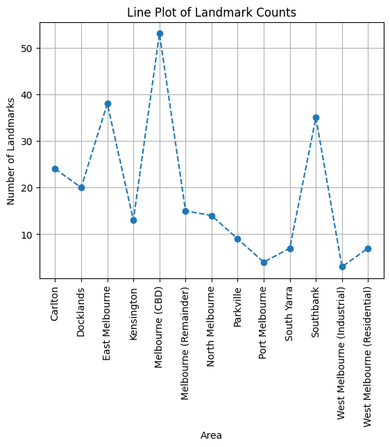

```python
# Create a line plot
plt.plot(landmark_counts.index, landmark_counts, marker='o', linestyle='--')

# Add labels and title
plt.xlabel('Area')
plt.ylabel('Number of Landmarks')
plt.title('Line Plot of Landmark Counts')

# Rotate x-axis labels for better readability
plt.xticks(rotation=90)

plt.grid(True)
plt.show()
```

# Landmark Density

```python
landmarks_in_suburb['shape_area'] = landmarks_in_suburb['shape_area'].astype(float)

# Converting values in 'shape_area' sqkm
landmarks_in_suburb['shape_area'] /= 1e+6

# Dividing values from 'Landmark_Count' by  values from 'shape_area'
landmarks_in_suburb['Landmark_Density'] = landmarks_in_suburb['Landmark_Count'] / landmarks_in_suburb['shape_area']
landmarks_in_suburb['Landmark_Density'] = landmarks_in_suburb['Landmark_Density'].round(1)

print(landmarks_in_suburb)
```

```
                          suburb  shape_area  Landmark_Count  Landmark_Density
2                Melbourne (CBD)    2.485905              53              21.3
7                 East Melbourne    1.909073              38              19.9
5                      Southbank    1.596010              35              21.9
10                       Carlton    2.724821              24               8.8
9                      Docklands    2.856029              20               7.0
3          Melbourne (Remainder)    2.668301              15               5.6
11               North Melbourne    2.408377              14               5.8
0                     Kensington    3.808797              13               3.4
4                      Parkville    4.050997               9               2.2
1   West Melbourne (Residential)    0.860055               7               8.1
6                    South Yarra    1.057773               7               6.6
12                Port Melbourne    5.470093               4               0.7
8    West Melbourne (Industrial)    5.917883               3               0.5
```

**Landmark Desity** column gives us the value for number of Landmarks per Square kilometer. The Suburbs with hgher value of Landmark Density indicate that the suburbs have more landmarks and places of interest given the size of data.

The following plot shows us the Landmark Density accross each suburb, this helps us understand which suburbs have a higher concentration of suburbs per square kilometer.

```python
# Creating interactive histogram
fig = px.histogram(landmarks_in_suburb, x='Landmark_Density', y='suburb', title='Landmark Density in Suburbs',
                   labels={'Landmark_Density': 'Landmark Density', 'suburb': 'Suburb'})


fig.show()
```

[interactive chart not shown]

# Most common Places of Interest/ Landmarks in each Suburb

**In the following section we will use data from the lndmvrks dataset where we ave categorised each landmark into the suburb it belongs by spatial analysis. For each suburb, we will find out the most common Type of landmarks and count the number of Type the most common Type of landmark appears in that suburb.**

```python
# Grouping by 'suburb' and 'Theme'
grouped = lndmvrks.groupby(['suburb', 'Theme']).size().reset_index(name='count')

# maximum count for each suburb
idx = grouped.groupby(['suburb'])['count'].transform(max) == grouped['count']

# Filtering the  to get the maximum count for each suburb
most_common_landmarks_df = grouped[idx]

most_common_landmarks_df.columns = ['suburb', 'most_common_landmark', 'landmark_count']

print(most_common_landmarks_df)
```

```
                          suburb most_common_landmark  landmark_count
3                        Carlton   Leisure/Recreation               8
7                      Docklands   Leisure/Recreation               7
16                East Melbourne   Leisure/Recreation              10
24                    Kensington   Leisure/Recreation               5
26                    Kensington            Transport               5
32               Melbourne (CBD)    Place Of Assembly              12
38         Melbourne (Remainder)   Leisure/Recreation               9
44               North Melbourne   Leisure/Recreation               3
46               North Melbourne     Place of Worship               3
48                     Parkville   Leisure/Recreation               7
51                Port Melbourne   Leisure/Recreation               2
57                   South Yarra     Place of Worship               3
63                     Southbank    Place Of Assembly              12
66   West Melbourne (Industrial)            Mixed Use               1
67   West Melbourne (Industrial)            Transport               1
68   West Melbourne (Industrial)      Warehouse/Store               1
71  West Melbourne (Residential)     Place of Worship               3
```

```python
import plotly.graph_objects as go

# Creating a bar plot
fig = go.Figure(data=[go.Bar(
    x=most_common_landmarks_df['suburb'],
    y=most_common_landmarks_df['landmark_count'],
    text=most_common_landmarks_df['most_common_landmark'],


)])

# Update layout
fig.update_layout(
    xaxis=dict(title='Suburb'),
    yaxis=dict(title='Most Common Theme Count'),
    title='Most Common Theme Count for Each Suburb',
    xaxis_tickangle=-45,  # Rotate x-axis labels
    barmode='group',  # Choose the mode of the bars
)

fig.show()
```

[interactive chart not shown]

**In the above plot we can obsereve some of the suburbs have a stacked bar plot, this is due to the fact that these suburbs have two or more Types of landmarks that are tied for being the most common Type of landmark in the suburb.**

# Landmarks in Each Suburb

**In the section below, we have made a filter which can provide information about any given suburb and the Type of landmarks it contains. Users can specify the Type of landmarks and the Type of suburbs to obtain a count of the number of landmarks of a specified Type exist within a specific suburb, further it also shows the distribution of the specified landmark Type into its various sub Types.**

```python
#defining a function
def plot_subthemes_by_theme_and_suburb(data):
    suburb = input("Enter the name of the suburb: ")
    theme = input("Enter the name of the theme: ")

    filtered_data = data[(data['suburb'] == suburb) & (data['Theme'] == theme)]

    if filtered_data.empty:
        print("No data found for the specified suburb and theme.")
    else:
        subtheme_counts = filtered_data['Sub Theme'].value_counts().reset_index()
        subtheme_counts.columns = ['Sub Theme', 'Count']

        total_theme_counts = len(filtered_data)

                # Printing total number of theme counts
        print(f"\033[1m\n Total number of {theme} counts in {suburb}: {total_theme_counts}\033[0m")



        # Plotting
        fig = px.bar(subtheme_counts, x='Sub Theme', y='Count',
                     title=f'Subtheme Counts for {theme} in {suburb}',
                     labels={'Subtheme': 'Subtheme', 'Count': 'Count'})
        fig.update_layout(xaxis_tickangle=-45, xaxis_title=None, yaxis_title='Count')
        fig.show()



# Example usage:
plot_subthemes_by_theme_and_suburb(lndmvrks)
```

```
Enter the name of the suburb: Carlton
Enter the name of the theme: Leisure/Recreation

 Total number of Leisure/Recreation counts in Carlton: 8
```

[interactive chart not shown]